# Session 2: Homework 1

Group 7: Sarah Jiang, Danqing Sun, Lasse Munk, Shawn Wu, Pieter Vercruysse, Christian Pizzuti

2020-10-17

# 1 Returns of financial stocks

We will use the `tidyquant` package to download historical data of stock prices, calculate returns, and examine the distribution of returns.

We must first identify which stocks we want to download data for, and for this we must know their ticker symbol; Apple is known as AAPL, Microsoft as MSFT, McDonald’s as MCD, etc. The file `nyse.csv` contains 508 stocks listed on the NYSE, their ticker `symbol`, `name`, the IPO (Initial Public Offering) year, and the sector and industry the company is in.

```r
nyse <- read_csv(here::here("data","nyse.csv"))
```

Based on this dataset, create a table and a bar plot that shows the number of companies per sector, in descending order

```r
nyse_sector <- nyse %>%
  group_by(sector) %>%
  summarise(num_companies=n()) %>%
  arrange(desc(num_companies))

nyse_sector
```

```
## # A tibble: 12 x 2
##    sector                num_companies
##    <chr>                         <int>
##  1 Finance                          97
##  2 Consumer Services                79
##  3 Public Utilities                 60
##  4 Capital Goods                    45
##  5 Health Care                      45
##  6 Energy                           42
##  7 Technology                       40
##  8 Basic Industries                 39
##  9 Consumer Non-Durables            31
## 10 Miscellaneous                    12
## 11 Transportation                   10
## 12 Consumer Durables                 8
```

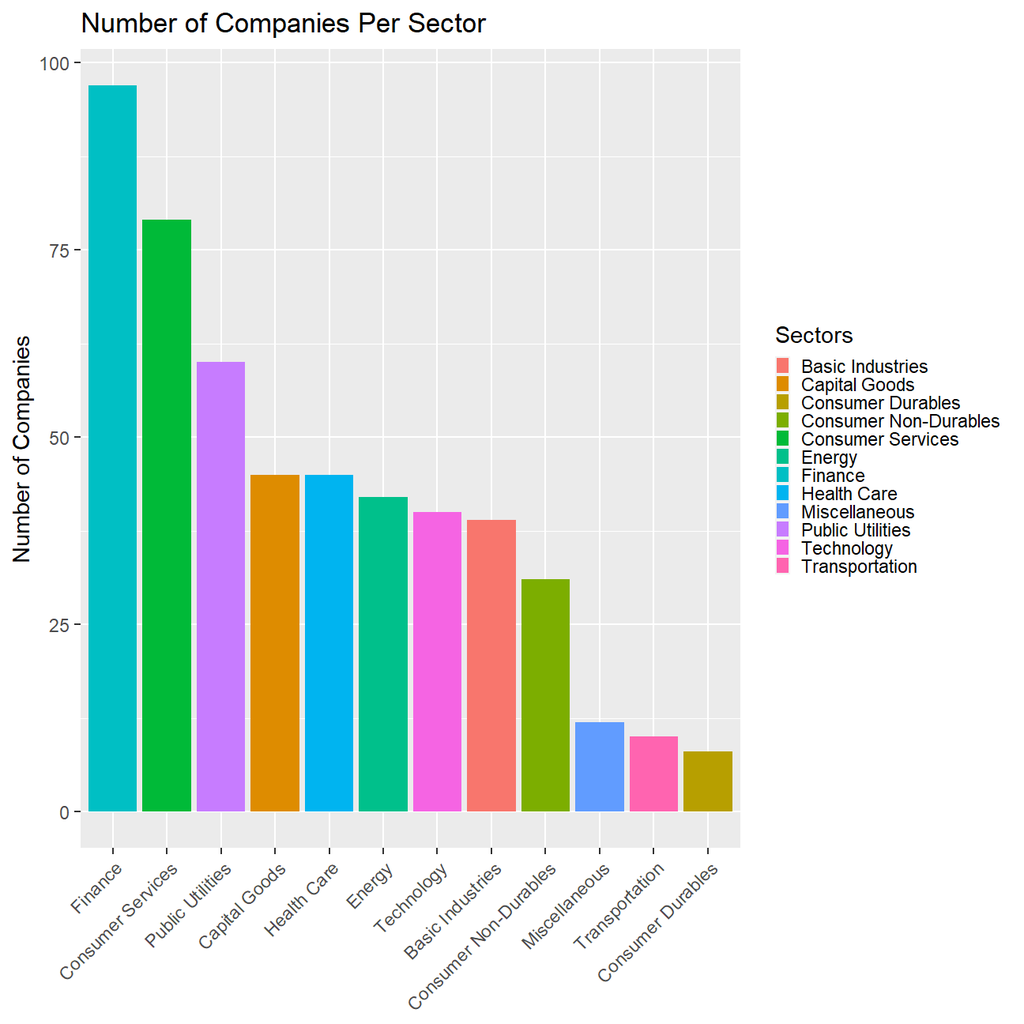

```r
nyse_sector %>%
  ggplot(aes(x=reorder(sector,-num_companies),
  y=num_companies, fill=sector)) +
  geom_bar(stat = 'identity') +
   ylab("Number of Companies") +
  labs(fill = "Sectors",title = "Number of Companies Per Sector") +
  theme(axis.text.x = element_text(angle = 45, hjust = 1),
        legend.key.size = unit(0.25, "cm"),
        axis.title.x = element_blank())
```

Next, let’s choose the [Dow Jones Industrial Aveareg (DJIA)](https://en.wikipedia.org/wiki/Dow_Jones_Industrial_Average) stocks and their ticker symbols and download some data. Besides the thirty stocks that make up the DJIA, we will also add `SPY` which is an SP500 ETF (Exchange Traded Fund).

```r
djia_url <- "https://en.wikipedia.org/wiki/Dow_Jones_Industrial_Average"

#get tables that exist on URL
tables <- djia_url %>%
  read_html() %>%
  html_nodes(css="table")


# parse HTML tables into a dataframe called djia.
# Use purr::map() to create a list of all tables in URL
djia <- map(tables, . %>%
               html_table(fill=TRUE)%>%
               clean_names())


# constituents
table1 <- djia[[2]] %>% # the second table on the page contains the ticker symbols
  mutate(date_added = ymd(date_added),

         # if a stock is listed on NYSE, its symbol is, e.g., NYSE: MMM
         # We will get prices from yahoo finance which requires just the ticker

         # if symbol contains "NYSE*", the * being a wildcard
         # then we jsut drop the first 6 characters in that string
         ticker = ifelse(str_detect(symbol, "NYSE*"),
                          str_sub(symbol,7,11),
                          symbol)
         )

# we need a vector of strings with just the 30 tickers + SPY
tickers <- table1 %>%
  select(ticker) %>%
  pull() %>% # pull() gets them as a sting of characters
  c("SPY") # and lets us add SPY, the SP500 ETF
```

```r
# Notice the cache=TRUE argument in the chunk options. Because getting data is time consuming, # cache=TRUE means that once it downloads data, the chunk will not run again next time you knit your Rmd

myStocks <- tickers %>%
  tq_get(get  = "stock.prices",
         from = "2000-01-01",
         to   = "2020-08-31") %>%
  group_by(symbol)

glimpse(myStocks) # examine the structure of the resulting data frame
```

```
## Rows: 153,121
## Columns: 8
## Groups: symbol [31]
## $ symbol   <chr> "MMM", "MMM", "MMM", "MMM", "MMM", "MMM", "MMM", "MMM", "M...
## $ date     <date> 2000-01-03, 2000-01-04, 2000-01-05, 2000-01-06, 2000-01-0...
## $ open     <dbl> 48.0, 46.4, 45.6, 47.2, 50.6, 50.2, 50.4, 51.0, 50.7, 50.4...
## $ high     <dbl> 48.2, 47.4, 48.1, 51.2, 51.9, 51.8, 51.2, 51.8, 50.9, 50.5...
## $ low      <dbl> 47.0, 45.3, 45.6, 47.2, 50.0, 50.0, 50.2, 50.4, 50.2, 49.5...
## $ close    <dbl> 47.2, 45.3, 46.6, 50.4, 51.4, 51.1, 50.2, 50.4, 50.4, 49.7...
## $ volume   <dbl> 2173400, 2713800, 3699400, 5975800, 4101200, 3863800, 2357...
## $ adjusted <dbl> 28.1, 26.9, 27.7, 30.0, 30.5, 30.4, 29.9, 30.0, 30.0, 29.5...
```

Financial performance analysis depend on returns; If I buy a stock today for 100 and I sell it tomorrow for 101.75, my one-day return, assuming no transaction costs, is 1.75%. So given the adjusted closing prices, our first step is to calculate daily and monthly returns.

```r
#calculate daily returns
myStocks_returns_daily <- myStocks %>%
  tq_transmute(select     = adjusted,
               mutate_fun = periodReturn,
               period     = "daily",
               type       = "log",
               col_rename = "daily_returns",
               cols = c(nested.col))

#calculate monthly  returns
myStocks_returns_monthly <- myStocks %>%
  tq_transmute(select     = adjusted,
               mutate_fun = periodReturn,
               period     = "monthly",
               type       = "arithmetic",
               col_rename = "monthly_returns",
               cols = c(nested.col))

#calculate yearly returns
myStocks_returns_annual <- myStocks %>%
  group_by(symbol) %>%
  tq_transmute(select     = adjusted,
               mutate_fun = periodReturn,
               period     = "yearly",
               type       = "arithmetic",
               col_rename = "yearly_returns",
               cols = c(nested.col))
```

Create a dataframe and assign it to a new object, where you summarise monthly returns since 2017-01-01 for each of the stocks and `SPY`; min, max, median, mean, SD.

```r
summary_monthly_returns <- myStocks_returns_monthly %>%
  filter(date>=ymd('2017-01-01')) %>%
  group_by(symbol) %>%
  summarise(mininum=min(monthly_returns),maximum=max(monthly_returns),
            median=median(monthly_returns),mean=mean(monthly_returns),
            standard_deviation=sd(monthly_returns))
summary_monthly_returns
```

```
## # A tibble: 31 x 6
##    symbol mininum maximum   median      mean standard_deviation
##    <chr>    <dbl>   <dbl>    <dbl>     <dbl>              <dbl>
##  1 AAPL    -0.181  0.200   0.0513   0.0387               0.0873
##  2 AMGN    -0.104  0.180   0.0235   0.0171               0.0664
##  3 AXP     -0.221  0.0988  0.0150   0.0109               0.0639
##  4 BA      -0.458  0.257   0.0250   0.0124               0.120
##  5 CAT     -0.199  0.138   0.0318   0.0151               0.0742
##  6 CRM     -0.155  0.391   0.0403   0.0350               0.0850
##  7 CSCO    -0.155  0.130   0.0185   0.0125               0.0673
##  8 CVX     -0.224  0.270   0.00173 -0.000926             0.0748
##  9 DIS     -0.179  0.234  -0.00208  0.00967              0.0750
## 10 DOW     -0.276  0.255   0.0456   0.00898              0.128
## # ... with 21 more rows
```

Plot a density plot, using `geom_density()`, for each of the stocks

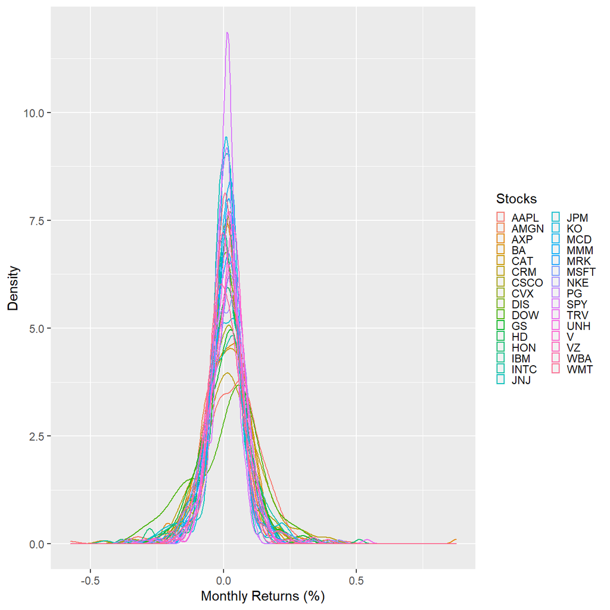

```r
  myStocks_returns_monthly %>%
  ggplot(aes(x=monthly_returns, color=symbol)) +
  geom_density() +
  theme(legend.key.size = unit(0.25, "cm")) +
  xlab("Monthly Returns (%)") + ylab("Density") +labs(color="Stocks")
```

What can you infer from this plot? Which stock is the riskiest? The least risky?

> TYPE YOUR ANSWER AFTER (AND OUTSIDE!) THIS BLOCKQUOTE.  
> Upon a visual inspection, it would appear that Dow Inc. (DOW) is the riskiest stock, due to its distribution being the most wide-spread. On the other hand, the S&P 500 index (SPY) appears to be the least risky, as it has the greatest “peakedness”.

Finally, produce a plot that shows the expected monthly return (mean) of a stock on the Y axis and the risk (standard deviation) in the X-axis. Please use `ggrepel::geom_text_repel()` to label each stock with its ticker symbol

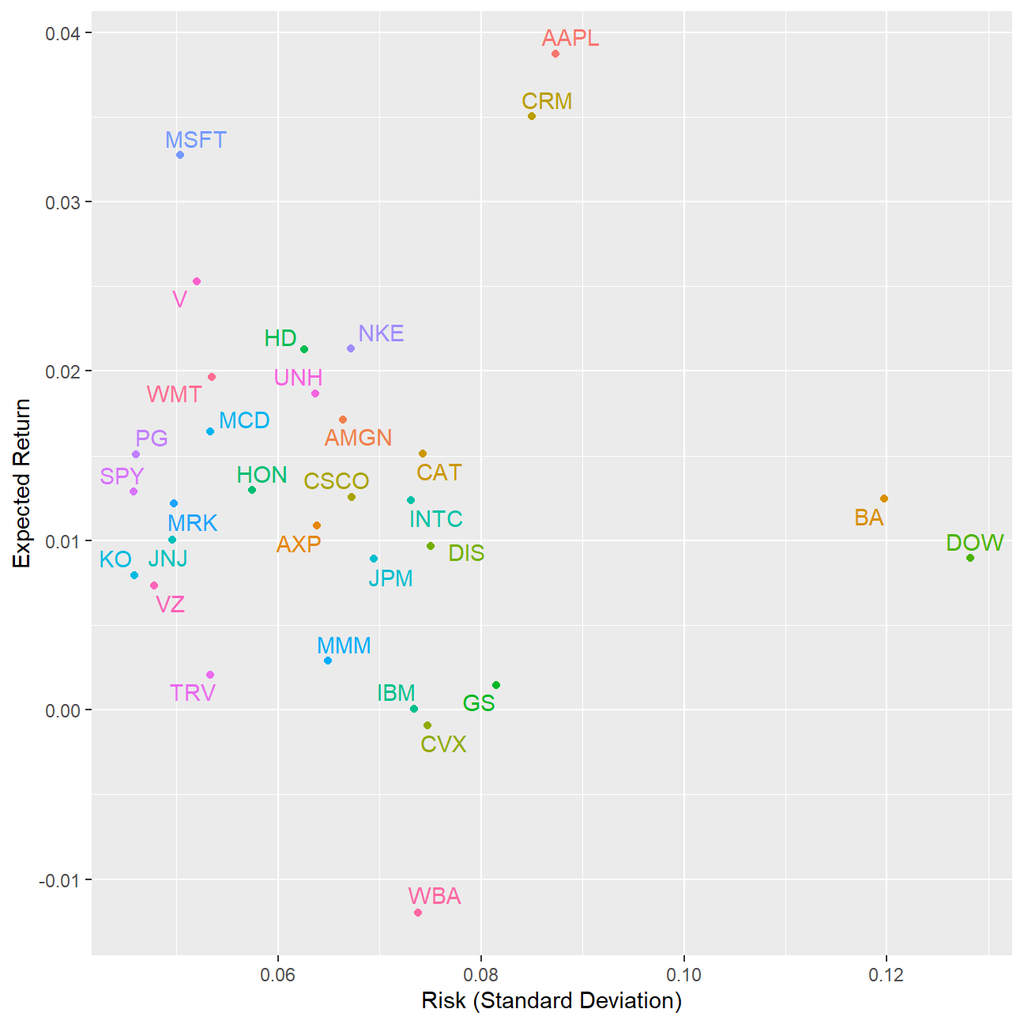

```r
summary_monthly_returns %>%
  ggplot(aes(x=standard_deviation, y=mean, color=symbol, label=symbol)) +
  geom_point() +
  theme(legend.position = "none") +
  ggrepel::geom_text_repel() +
  xlab("Risk (Standard Deviation)") +
  ylab("Expected Return")
```

What can you infer from this plot? Are there any stocks which, while being riskier, do not have a higher expected return?

> TYPE YOUR ANSWER AFTER (AND OUTSIDE!) THIS BLOCKQUOTE.  
> In general, stocks that are riskier also have higher expected returns (positive relationship between expected return and risk). The Boeing Company (BA) and Dow Inc. (DOW) stand out as two of the stocks with the highest measure of risk, while not having the commensurate level of expected return. In essence, there are a lot of other stocks that can generate the same or even higher levels of expected return, at a much lower level of risk than The Boeing Company (BA) and Dow Inc. (DOW).